# R Shiny Workshop

February 3, 2026

## What is R Shiny?

> Shiny is an R package that makes it easy to build interactive web applications (apps) straight from R

R language is translated into the language(s) of the web (JavaScript, CSS, HTML)

Can have R data processing in the background

Classic R plotting aesthetics - but interactive, so users can explore data for themselves!

## Some inspiration

[Fertility statistics](https://fluxapp.utu.fi/)

[Crisis vaccination planner](https://shiny.dide.imperial.ac.uk/)

[Lyme disease overview](https://www.hopkinslymetracker.org/overview/)

[Wastewater monitoring of infectious diseases](https://wise.ethz.ch/)

## Basic app set up

[figure not shown]

[figure not shown]

1. Select Shiny Web App
2. Give your application a name
3. Select the directory for saving
4. Click create

## User interface (ui)

```r
# Define UI for application that draws a histogram
ui <- fluidPage(

    # Application title
    titlePanel("Old Faithful Geyser Data"),

    # Sidebar with a slider input for number of bins
    sidebarLayout(
        sidebarPanel(
            sliderInput("bins",
                        "Number of bins:",
                        min = 1,
                        max = 50,
                        value = 30)
        ),

        # Show a plot of the generated distribution
        mainPanel(
           plotOutput("distPlot")
        )
    )
)
```

## Server

```r
# Define server logic required to draw a histogram
server <- function(input, output) {

    output$distPlot <- renderPlot({
        # generate bins based on input$bins from ui.R
        x    <- faithful[, 2]
        bins <- seq(min(x), max(x), length.out = input$bins + 1)

        # draw the histogram with the specified number of bins
        hist(x, breaks = bins, col = 'darkgray', border = 'white',
             xlab = 'Waiting time to next eruption (in mins)',
             main = 'Histogram of waiting times')
    })
}
```

## Building blocks

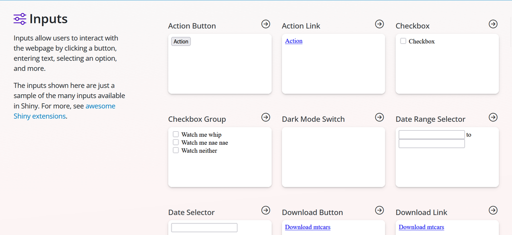

## Building blocks (cont.)

[figure not shown]

## Building blocks (cont.)

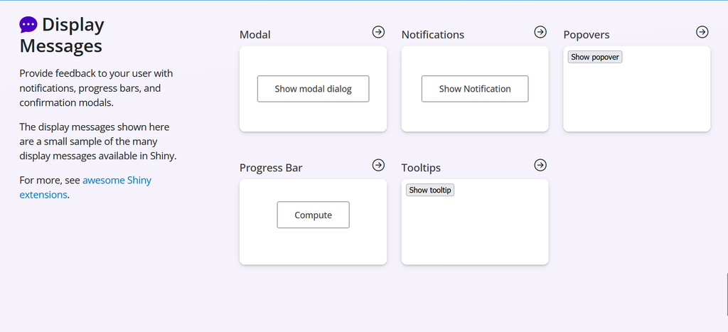

## Exploring wastewater

Data is from wastewater monitoring project in Switzerland.

Monitor wastewater treatment plants around the country for various infectious diseases.

They have an [API](https://wisedb.ethz.ch/api/docs/) where they share data publicly.

## Hands on time!

Download example app `exploring-wastewater/app.R` from [GitHub](https://github.com/emmaSkarstein/R-Ladies-Trondheim).

[figure not shown]

## Some challenges

- Add a [date range selector](https://shiny.posit.co/r/components/inputs/date-range-selector/) for the graph
- Create a [card](https://pkgs.rstudio.com/bslib/articles/cards/) in the viruses page for each different target in the data set (advanced challenge do this with a function)
- Add another [navigation panel](https://pkgs.rstudio.com/bslib/reference/nav-items.html) “Locations” to compare all viruses for a particular wastewater treatment plant
- Ensure plot colours are consistent for each virus/wwtp selected in the graph
- Make a plot interactive using [`ggplotly`](https://www.statology.org/how-to-use-ggplot2-with-plotly-in-r-for-interactive-visualizations/)
- [Change the colour](https://rstudio.github.io/bslib/articles/utility-classes/index.html#add-background-color) of the header of a card
- Add a [notification](https://shiny.posit.co/r/components/display-messages/notifications/) when the wwtp is changed

## More advanced things

[Modules](https://shiny.posit.co/r/articles/improve/modules/) - efficient re-use of code, avoid copy-paste!

[`leaflet`](https://rstudio.github.io/leaflet/articles/shiny.html) - interactive maps

[`bslib` theming](https://unleash-shiny.rinterface.com/beautify-with-bootstraplib.html) - tailoring aesthetics

[`i18n`](https://appsilon.github.io/shiny.i18n/index.html) - multi-language set-ups

[`shinymanager`](https://datastorm-open.github.io/shinymanager/) - password protecting apps

[`golem`](https://thinkr-open.github.io/golem/) - structured framework for production-grade apps

## Sources and resources

[Shiny’s introduction](https://shiny.posit.co/r/getstarted/shiny-basics/lesson1/)

[Shiny cheat sheet](https://raw.githubusercontent.com/rstudio/cheatsheets/main/shiny.pdf)

[Carpentry course (pre alpha!)](https://umn-dash.github.io/r-shiny/index.html)